# Spatial-Temporal Distribution of Kinkajous in a Balsa Tree

### Adjusted Flower Counts

For testing our hypotheses, we need to investigate not only how the number of flowers in each region affects kinkajou behavior, but how the relative abundance between regions affects kinkajou behavior. To do this, we determine the average proportion of flowers counted in each region over the full course of the study (eg, Region 1 typically has 0.30 of the total flowers in the tree crown on a given night). We then use this proportion to determine the expected number of flowers in each region for each night, given the total number of flowers. Finally, we subtract this expected flower count from the actual counts in each region to get deviations from the expectation. By using these deviations as predictors of kinkajou behavior, we can test the effects of increases or decreases in the relative abundance of flowers within regions.

```r
flower_counts_region <- flower_counts_region %>% mutate(Relative_Density = Density - flower_counts$Density[pmatch(Study_night, flower_counts$Study_night, duplicates.ok = TRUE)]) #match study_nights between regional and full tree flower count data, subtracting the full tree flower density from each regional density for each night

flower_counts_region$Expected_Relative_Density <- NA
for(i in 1:nrow(flower_counts_region)){
  flower_counts_region$Expected_Relative_Density[i] <- mean(filter(flower_counts_region,
                                                                   Study_night < flower_counts_region$Study_night[i] &
                                                                     Region == flower_counts_region$Region[i])$Relative_Density)
}

#flower_averages are used in next code chunk to calculate adjusted values
flower_averages <- flower_counts_region %>%
  group_by(Region) %>%
  summarize(total_flowers = sum(Count)) %>%
  mutate(proportion = total_flowers/sum(total_flowers))
```

## Integrated Data-Structures

Next, we put all of the nightly kinkajou and flower count data together into a single dataframe so they can be easily visualized jointly. First, we integrate flower counts and residence time data

```r
combined_data <- merge(flower_counts, kinkajou_counts, by = "Study_night", all = TRUE)

combined_data_region <- merge(flower_counts_region, kinkajou_counts_region, by = c("Study_night","Region") , all = TRUE) %>%
  mutate(Total_Flowers = combined_data$Count[pmatch(Study_night, combined_data$Study_night, duplicates.ok = TRUE)]) %>%
  mutate(Adjusted_Count = Count - (Total_Flowers * flower_averages$proportion[Region]),
         Average_Density = 10 * Total_Flowers/sum(st_area(region_shapes))) #get desnity in flowers/10m^2
```

### Transition Decisions

Then, we extract from all transitions those that reflect binary “decisions” (i.e. movement from one region to a different region). We annote these decisions with adjusted flower counts in the region moved to and the region avoided, setting up the data-frame to enable analysis of decisions with a binary response. In this response, a 1 indicates that the kinkajou moved to the region with the higher adjusted flower count.

```r
decisions <- c()
for(i in seq_along(transition_arrays)){
  new_decisions <- get_decision_info(transition_array = transition_arrays[[i]], flower_data = filter(combined_data_region, Study_night == names(transition_arrays[i]))) #see helper functions for get_decision_info
  if(nrow(new_decisions) > 0) new_decisions$Study_night = names(transition_arrays[i])
  decisions = rbind(decisions, new_decisions)
}
decisions <- mutate(decisions, relative_density_diff = relative_density_to - relative_density_avoid)
decisions <- mutate(decisions, Success = relative_density_diff > 0)
```

# Data Visualization

With the data prepared, we visualize spatio-temporal patterns of both flowers and kinkajous within the tree-crown as a whole and within regions of the tree crown. Based on our hypotheses, we made some predictions about patterns we expected to see.

First, under Hypothesis A (Kinkajous prefer to forage in regions with greater densities of flowers), we predicted that kinkajous would spend more time in the tree crown, as a whole, when overall flower densities were higher. Under the same hypothesis, we predicted that kinkajous would spend more time in regions of the tree with greater flower density, relative to other regions.

## Kinkajous Residence Times

Below, we visualize the kinkajou counts per region, per night, over the course of the study.

Plotting the data in bar charts gives a good sense of the relative time spent in each region by kinkajous. However, these total counts may be influenced by the duration of observations on that night.

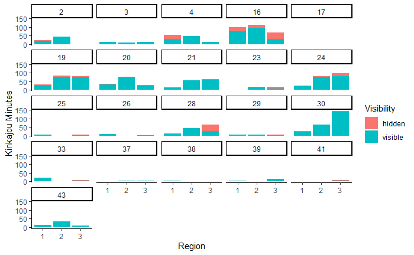

```r
ggplot(all_kinkajou_scans_long) +
  geom_bar(aes(x = Region, weight = Count, fill = Visibility)) +
  facet_wrap(~Study_night) +
  theme_classic() +
  labs(y = "Kinkajou Minutes")
```

A line plot with study night on the x axis makes clear the periods of time in which observation did not occur. Here, we convert total kinkajou minutes to kinkajou minutes per hour. The data plotted this way highlight temporal trends in overall kinkajou residence in the tree . . .

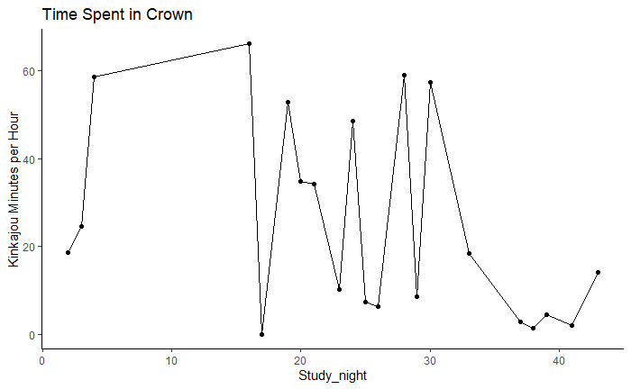

```r
ggplot(all_kinkajou_scans_long, aes(x = Study_night, y = Count)) + stat_summary(fun = "get_kinkMinutesPerHour", geom = "line") + stat_summary(fun = "get_kinkMinutesPerHour", geom = "point") +
  theme_classic() +
  labs(title = "Time Spent in Crown", y = "Kinkajou Minutes per Hour")
```

. . . and kinkajou residence times by region

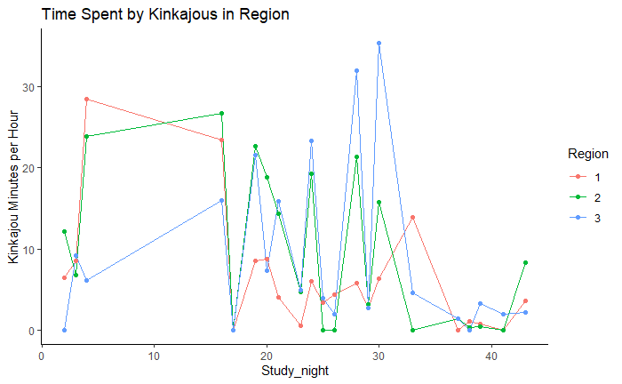

```r
ggplot(kinkajou_counts_region, aes(x = Study_night, y = Minutes_Per_Hour, color = Region)) + geom_line(stat = "identity") + geom_point(stat = "identity") +
  theme_classic() +
  labs(title = "Time Spent by Kinkajous in Region", y = "Kinkajou Minutes per Hour")
```

## Flower Counts

As with Kinkajou Residence Times, we can plot the total number of flowers over study.

We look first at the counts of all drone flights to check that AM and PM flights are loargely in Agreement

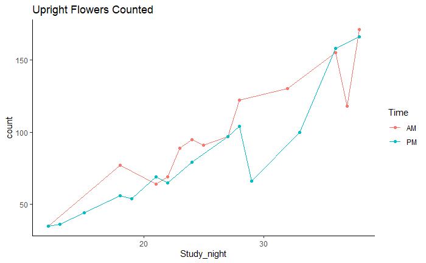

```r
ggplot(mutate(all_upflowers, Study_night = Study_night - (Time == "AM")), aes(x = Study_night, color = Time)) + geom_line(stat = "count") + geom_point(stat = "count") +
  theme_classic() +
  labs(title = "Upright Flowers Counted")
```

Then we look at the flower counts after averaging AM and PM scans. First, total counts

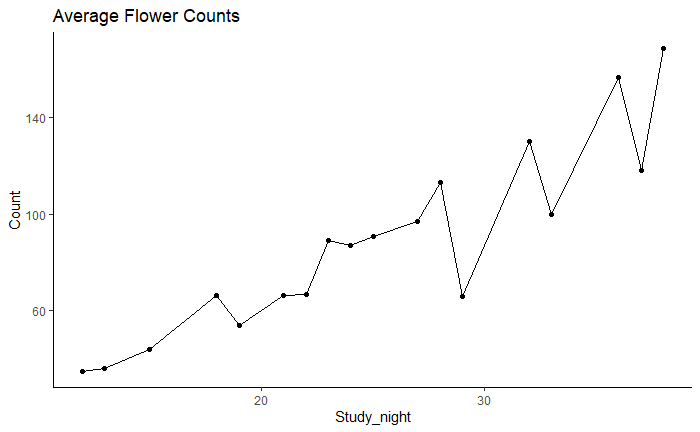

```r
ggplot(flower_counts, aes(x = Study_night, y = Count)) +
  geom_line(stat = "identity") +
  geom_point(stat = "identity") +
  theme_classic() +
  labs(title = "Average Flower Counts")
```

And then the counts by region

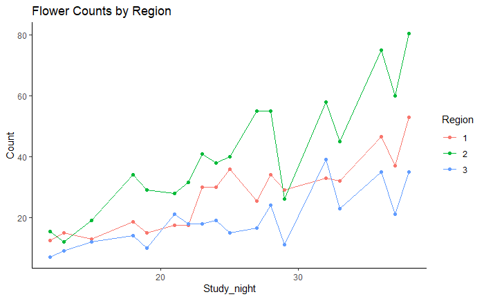

```r
ggplot(flower_counts_region, aes(x = Study_night, y = Count, color = Region)) + geom_line(stat = "identity") + geom_point(stat = "identity") +
  theme_classic() +
  labs(title = "Flower Counts by Region")
```

Because the regions differ in size, it is probably better to consider flwoer densitites in each region, rather than total flower counts.

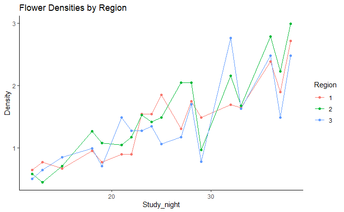

```r
ggplot(flower_counts_region, aes(x = Study_night, y = Density, color = Region)) + geom_line(stat = "identity") + geom_point(stat = "identity") +
  theme_classic() +
  labs(title = "Flower Densities by Region")
```

Because we are interested in how relative changes in flower counts between regions affects kinkajous’ movements, we can look at these data another way by adjusting the counts based on expected values. More precisely, this adjusted measure is the observed number of flowers in a region minus the proportion of total flowers observed in that region over the full study times the total number of flowers in the tree that night. This adjusted measure tells us how many more or less flowers are in a region each night than expected based on typical flower distributions in the crown

$$Adjusted Flower Count_{r,t} = Flower
Count_{r,t} - \frac{\sum_{t=1}^{T}Flower
Count_{r,t}}{\sum_{r=1}^{R}\sum_{t=1}^{T}Flower Count_{r,t}} *
\sum_{r=1}^{R}Flower Count_{r,t}$$

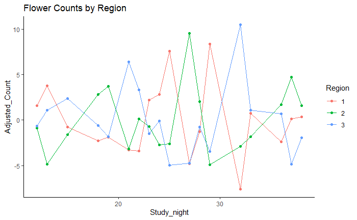

```r
ggplot(combined_data_region[!is.na(combined_data_region$Count),], aes(x = Study_night, y = Adjusted_Count, color = Region)) + geom_line(stat = "identity") + geom_point(stat = "identity") +
  theme_classic() +
  labs(title = "Flower Counts by Region")
```

Another way of looking at this is by using the relative density of the region, which gives the difference, in flowers per square meter, of the density in each region relative to the whole tree on the same night. These values can also be compared to expected relative densities, calculated by averaging the relative densities observes on all previous nights, and plotted below as dashed lines

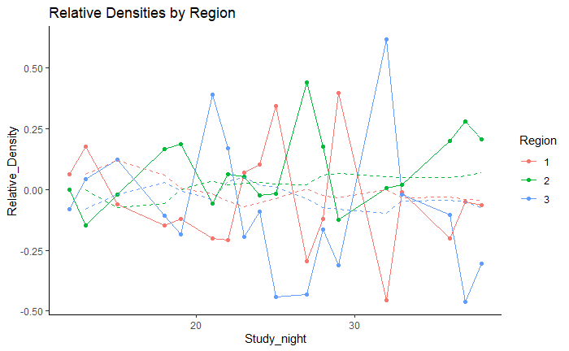

```r
ggplot(flower_counts_region, aes(x = Study_night, y = Relative_Density, color = Region)) + geom_line(stat = "identity") + geom_point(stat = "identity") +
  theme_classic() +
  geom_line(aes(y = Expected_Relative_Density), linetype = "dashed") +
  labs(title = "Relative Densities by Region")
```

```r
#need to add legend for Observed (solid) and Expected (Dashed)
```

## Kinkajou Residence-Flower Interactions

To visualize changes in flower counts and kinkajou residence time together, over the course of the study, we use a growth index which gives the percent change in count or residence time relative to the first respective observation. This ensures the scale of both data types remains the same, and allows unbiased visualization of their relationship.

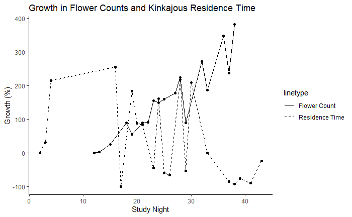

```r
ggplot(flower_counts, aes(x = Study_night, y = Growth)) +
  geom_line(aes(linetype = "Flower Count"), stat = "identity") +
  geom_point(stat = "identity") +
  geom_line(mapping = aes(linetype = "Residence Time"), data = kinkajou_counts, stat = "identity") +
  geom_point(data = kinkajou_counts, stat = "identity") +
  theme_classic() +
  scale_color_discrete(name = "Flower Count") +
  scale_linetype_manual(values = c("Flower Count" = "solid", "Residence Time" = "dashed")) +
  labs(#title = "Growth in Minutes per Hour Kinkajous spend in a balsa crown (black dotted) \n and balsa flower counts (solid) over study period",
       y = "Growth (%)",
       x = "Study Night",
       title = "Growth in Flower Counts and Kinkajous Residence Time")
```

In the plot above, we see an increase with flower counts over time. Kinkajou residence on the other hand does not appear to have a trend until it drops off toward the end of the study. This runs counter to our prediction drawn from Hypothesis A that kinkajous would spend more time in the three when there were more flowers. However, we do not have data on the other resources available in the kinkajous’ environment. Toward the end of our study period, other resources would likely have been coming into season, and thus the balsa tree may have been less attractive relative to other resources in the kinkajous’ environment, despite the its increasing flower count.

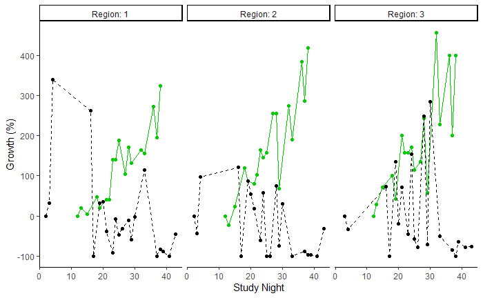

```r
#still need to get a legend working on this
ggplot(flower_counts_region, aes(x = Study_night, y = Growth)) + geom_line(color = "green3", stat = "identity", linetype = "solid") + geom_point(stat = "identity", color = "green3") +
  geom_line(data = kinkajou_counts_region, linetype = "dashed") + geom_point(data = kinkajou_counts_region, color = "black") +
  theme_classic() +
  facet_wrap(~Region, labeller = "label_both") +
  theme(legend.position = "bottom") +
  scale_linetype_manual(name = "", values = c("Flower Count" = "solid", "Kinkajou Minutes Per Hour" = "dashed")) +
  labs(#title = "Growth in Minutes per Hour Kinkajous spend in a balsa crown (black) \n and balsa flower counts (solid) over study period",
       y = "Growth (%)",
       x = "Study Night")
```

Looking at flower counts and residence times by regions, there are not any strongly apparent differences in the interaction between balsa flowers and kinkajous.